# NOAA_Weather_Dataset

### Some Analysis of the NOAA weather dataset

In this notebook we are analyzing a sample out of data that was downloaded from http://www1.ncdc.noaa.gov/pub/data/ghcn/daily/, the main file is ghcnd_all.tar.gz which is about 2.4 GB which becomes around 20GB when uncompressed.

The data contains about 1 million station-year recordings. That is too much to analyzer on single core machine, so we start by taking a sample of 20,000 recordings of the maximal daily temperatures for a period of a 365 days starting on January 1st (the last day of leap years is discarded).

### Checking the versions of some important packages

```python
%pylab inline
import matplotlib.pyplot as plt
import pandas as pd
import numpy as np
import sklearn as sk
print 'pandas version: ',pd.__version__,'should be at least 0.14.0'
print 'numpy version:',np.__version__,'should be at least 1.8.1'
print 'sklearn version:',sk.__version__,'should be at least 0.14.1'
```

```
pandas version:  0.16.2 should be at least 0.14.0
numpy version: 1.10.1 should be at least 1.8.1
sklearn version: 0.16.1 should be at least 0.14.1
```

Switch to the data directory and check it's contents

```python
%cd ../data/weather/
#%cs ~/data/weather
!ls -lh
```

```
[Errno 2] No such file or directory: '../data/weather/'
/Users/mgalarny/Desktop/DSE200-notebooks/data/weather
total 159696
-rw-r--r--  1 mgalarny  staff   839K Oct 30 09:08 ALL.corrupted.csv
-rw-r--r--  1 mgalarny  staff   839K Oct 30 09:08 ALL.head.csv
-rw-r--r--  1 mgalarny  staff    25M Oct 30 09:08 SAMPLE_TMAX.csv
-rw-r--r--  1 mgalarny  staff    13K Oct 30 09:08 TMAX.10.csv
-rw-r--r--  1 mgalarny  staff     0B Oct 30 09:08 TMAX.head.csv
-rw-r--r--  1 mgalarny  staff   218B Oct 30 09:08 data-source.txt
-rw-r--r--  1 mgalarny  staff    22K Oct 30 09:08 ghcnd-readme.txt
-rw-r--r--  1 mgalarny  staff   7.0M Oct 30 09:08 ghcnd-stations.txt
-rw-r--r--  1 mgalarny  staff   7.4M Nov 12 00:13 ghcnd-stations_buffered.txt
-rw-r--r--  1 mgalarny  staff   270B Oct 30 09:08 ghcnd-version.txt
-rw-r--r--  1 mgalarny  staff    37M Oct 30 09:08 make_covar.raw_256
```

```python
!head -1 SAMPLE_TMAX.csv
# a Typical single line in the data file
```

```
USC00507570,TMAX,2005,67,44,61,17,-17,-22,-39,-44,-44,-78,-156,-156,-33,28,39,22,-89,-139,-156,44,61,50,-39,17,67,61,-61,-61,11,33,-72,-100,-150,-178,-150,-33,39,28,22,11,-150,-156,-150,50,44,28,39,50,56,39,67,50,39,56,50,56,44,22,6,17,17,61,83,67,67,89,78,61,61,83,56,44,67,89,67,89,100,83,56,17,22,…
```

### read data into a Pandas Dataframe

- Read the data into a DataFrame
- Read the data vectors in G
- Divide by 10.0 to get the temperatude in degrees celsius
- Replace values outside the range [-400,500] ([-40,50] degrees celsius) with nan
- Paste fixed matrix back into Dout
- Show the first few lines of DDout

```python
header=['station','measurement','year']+range(1,366)
# D=pandas.DataFrame(columns=header)
Data = pd.read_csv('SAMPLE_TMAX.csv',header=None,names=header)
print Data.info()
Data.head()
```

```
<class 'pandas.core.frame.DataFrame'>
Int64Index: 20000 entries, 0 to 19999
Columns: 368 entries, station to 365
dtypes: float64(365), int64(1), object(2)
memory usage: 56.3+ MB
None
```

|  | station | measurement | year | 1 | 2 | 3 | 4 | 5 | 6 | 7 | ... | 356 | 357 | 358 | 359 | 360 | 361 | 362 | 363 | 364 | 365 |
| --- | --- | --- | --- | --- | --- | --- | --- | --- | --- | --- | --- | --- | --- | --- | --- | --- | --- | --- | --- | --- | --- |
| 0 | USC00507570 | TMAX | 2005 | 67 | 44 | 61 | 17 | -17 | -22 | -39 | ... | -39 | -33 | -17 | 39 | 61 | 50 | 61 | 61 | 44 | 61 |
| 1 | NOE00135018 | TMAX | 1959 | NaN | NaN | NaN | NaN | NaN | NaN | NaN | ... | 58 | 31 | 45 | 42 | 32 | 16 | 20 | 22 | 39 | 61 |
| 2 | KZ000036546 | TMAX | 1982 | NaN | NaN | -139 | NaN | NaN | -45 | NaN | ... | NaN | -73 | NaN | NaN | NaN | -170 | -166 | -160 | -135 | -99 |
| 3 | USC00054664 | TMAX | 1964 | NaN | NaN | NaN | NaN | NaN | NaN | NaN | ... | 94 | 78 | 33 | NaN | NaN | 39 | 56 | -39 | -150 | -150 |
| 4 | CUW00011706 | TMAX | 1981 | 300 | 283 | 300 | 300 | 283 | 289 | 289 | ... | 300 | 311 | 322 | 311 | 311 | 322 | 322 | 311 | 311 | 311 |

5 rows × 368 columns

```python
#Get all rows and take column 1 to 368
G=Data.ix[:,3:368]
G.head()
```

|  | 1 | 2 | 3 | 4 | 5 | 6 | 7 | 8 | 9 | 10 | ... | 356 | 357 | 358 | 359 | 360 | 361 | 362 | 363 | 364 | 365 |
| --- | --- | --- | --- | --- | --- | --- | --- | --- | --- | --- | --- | --- | --- | --- | --- | --- | --- | --- | --- | --- | --- |
| 0 | 67 | 44 | 61 | 17 | -17 | -22 | -39 | -44 | -44 | -78 | ... | -39 | -33 | -17 | 39 | 61 | 50 | 61 | 61 | 44 | 61 |
| 1 | NaN | NaN | NaN | NaN | NaN | NaN | NaN | NaN | NaN | NaN | ... | 58 | 31 | 45 | 42 | 32 | 16 | 20 | 22 | 39 | 61 |
| 2 | NaN | NaN | -139 | NaN | NaN | -45 | NaN | NaN | -28 | NaN | ... | NaN | -73 | NaN | NaN | NaN | -170 | -166 | -160 | -135 | -99 |
| 3 | NaN | NaN | NaN | NaN | NaN | NaN | NaN | NaN | NaN | NaN | ... | 94 | 78 | 33 | NaN | NaN | 39 | 56 | -39 | -150 | -150 |
| 4 | 300 | 283 | 300 | 300 | 283 | 289 | 289 | 311 | 300 | 294 | ... | 300 | 311 | 322 | 311 | 311 | 322 | 322 | 311 | 311 | 311 |

5 rows × 365 columns

```python
#Get values is less than -400 or greater than 500, and set them to nan
G[G<-400]=np.nan   #remove outliers
G[G>500]=np.nan
G=G/10   # temp / 10 is the temp in celsius
```

```python
Data.ix[:,3:368]=G
```

```python
G=G.transpose()
G.info()
```

```
<class 'pandas.core.frame.DataFrame'>
Index: 365 entries, 1 to 365
Columns: 20000 entries, 0 to 19999
dtypes: float64(20000)
memory usage: 55.7+ MB
```

```python
Data.head()
```

|  | station | measurement | year | 1 | 2 | 3 | 4 | 5 | 6 | 7 | ... | 356 | 357 | 358 | 359 | 360 | 361 | 362 | 363 | 364 | 365 |
| --- | --- | --- | --- | --- | --- | --- | --- | --- | --- | --- | --- | --- | --- | --- | --- | --- | --- | --- | --- | --- | --- |
| 0 | USC00507570 | TMAX | 2005 | 6.7 | 4.4 | 6.1 | 1.7 | -1.7 | -2.2 | -3.9 | ... | -3.9 | -3.3 | -1.7 | 3.9 | 6.1 | 5.0 | 6.1 | 6.1 | 4.4 | 6.1 |
| 1 | NOE00135018 | TMAX | 1959 | NaN | NaN | NaN | NaN | NaN | NaN | NaN | ... | 5.8 | 3.1 | 4.5 | 4.2 | 3.2 | 1.6 | 2.0 | 2.2 | 3.9 | 6.1 |
| 2 | KZ000036546 | TMAX | 1982 | NaN | NaN | -13.9 | NaN | NaN | -4.5 | NaN | ... | NaN | -7.3 | NaN | NaN | NaN | -17.0 | -16.6 | -16.0 | -13.5 | -9.9 |
| 3 | USC00054664 | TMAX | 1964 | NaN | NaN | NaN | NaN | NaN | NaN | NaN | ... | 9.4 | 7.8 | 3.3 | NaN | NaN | 3.9 | 5.6 | -3.9 | -15.0 | -15.0 |
| 4 | CUW00011706 | TMAX | 1981 | 30.0 | 28.3 | 30.0 | 30.0 | 28.3 | 28.9 | 28.9 | ... | 30.0 | 31.1 | 32.2 | 31.1 | 31.1 | 32.2 | 32.2 | 31.1 | 31.1 | 31.1 |

5 rows × 368 columns

```python
#Unstack a dataframe, it becomes Series
tmp=G.ix[:,:].unstack()
print tmp.shape, type(tmp), tmp.describe()
tmp.head()
```

```
(7300000,) <class 'pandas.core.series.Series'> count    6514859.000000
mean          16.522349
std           12.818221
min          -40.000000
25%            7.800000
50%           18.300000
75%           26.700000
max           50.000000
dtype: float64
```

```
0  1    6.7
   2    4.4
   3    6.1
   4    1.7
   5   -1.7
dtype: float64
```

```
-40.0 50.0
```

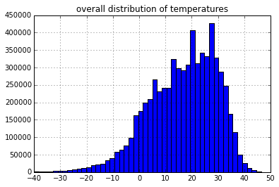

```python
#Plot the tempertures of 365 days of all the data 20,000
tmp.hist(bins=50);
title('overall distribution of temperatures')
print tmp.min(),tmp.max()
```

### Script for plotting yearly plots

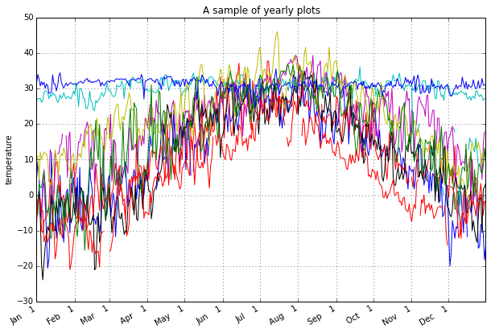

```python
from datetime import date
dates=[date.fromordinal(i) for i in range(1,366)]


#YearlyPlots takes tranpose data: day 1-365 on the index and temperatures on the column)
def YearlyPlots(T,ttl='',size=(10,7)):
    fig=plt.figure(1,figsize=size,dpi=300)
    #fig, ax = plt.subplots(1)
    if shape(T)[0] != 365:
        raise ValueError("First dimension of T should be 365. Shape(T)="+str(shape(T)))
    plot(dates,T);
    # rotate and align the tick labels so they look better
    fig.autofmt_xdate()
    ylabel('temperature')
    grid()
    title(ttl)

#Call YearlyPlots function
#Index of Data must start at column 3-368
YearlyPlots(Data.ix[20:30,3:368].transpose(),ttl='A sample of yearly plots')
```

### Plots for sydney, Australia

```python
#Return values of this embedded function is True or False in each cell of Data
sydneyStations=['ASN00066' in station for station in Data['station']]
print type(sydneyStations), len(sydneyStations)

#sydneyStations has 6 stations
print Data[sydneyStations]['station'].values
#True or False values
#print sydneyStations

Data[sydneyStations]
#Data[sydneyStations]['station']
```

```
<type 'list'> 20000
['ASN00066124' 'ASN00066059' 'ASN00066194' 'ASN00066131' 'ASN00066195'
 'ASN00066062']
```

|  | station | measurement | year | 1 | 2 | 3 | 4 | 5 | 6 | 7 | ... | 356 | 357 | 358 | 359 | 360 | 361 | 362 | 363 | 364 | 365 |
| --- | --- | --- | --- | --- | --- | --- | --- | --- | --- | --- | --- | --- | --- | --- | --- | --- | --- | --- | --- | --- | --- |
| 1859 | ASN00066124 | TMAX | 1987 | NaN | 24.0 | 27.0 | 31.5 | 31.5 | 31.0 | 31.5 | ... | 20.5 | 25.2 | 25.0 | 22.5 | 27.0 | 32.5 | 24.8 | 21.5 | 23.5 | 25.0 |
| 3177 | ASN00066059 | TMAX | 2010 | 26.4 | 28.3 | 19.4 | 22.9 | 26.6 | 27.0 | 23.9 | ... | 24.1 | 29.4 | 22.4 | 26.4 | 28.4 | 18.0 | 20.6 | 24.6 | 27.3 | 28.6 |
| 6402 | ASN00066194 | TMAX | 1995 | NaN | NaN | NaN | NaN | NaN | NaN | NaN | ... | 19.6 | 18.7 | 19.9 | 20.9 | 25.1 | 25.8 | 22.8 | 25.3 | 24.5 | 28.6 |
| 7604 | ASN00066131 | TMAX | 1964 | 29.8 | 27.8 | 31.1 | 27.1 | 28.1 | 35.0 | 40.6 | ... | 26.3 | 28.4 | 33.1 | 27.3 | 26.5 | 27.5 | 31.7 | 22.5 | 24.8 | 24.3 |
| 15856 | ASN00066195 | TMAX | 1998 | 32.7 | 34.9 | 36.5 | 24.4 | 26.0 | 25.3 | 26.0 | ... | 27.3 | 27.1 | 27.7 | 29.3 | 29.3 | 27.1 | 30.4 | 32.8 | 28.5 | 24.2 |
| 16912 | ASN00066062 | TMAX | 1985 | 24.4 | 29.2 | 27.3 | 25.9 | 34.9 | 24.4 | 27.5 | ... | 28.8 | 26.0 | 23.6 | 23.9 | 30.6 | 25.0 | 24.1 | 26.4 | 26.9 | 34.0 |

6 rows × 368 columns

```python
tmp=Data[sydneyStations].transpose()
tmp.head()
```

|  | 1859 | 3177 | 6402 | 7604 | 15856 | 16912 |
| --- | --- | --- | --- | --- | --- | --- |
| station | ASN00066124 | ASN00066059 | ASN00066194 | ASN00066131 | ASN00066195 | ASN00066062 |
| measurement | TMAX | TMAX | TMAX | TMAX | TMAX | TMAX |
| year | 1987 | 2010 | 1995 | 1964 | 1998 | 1985 |
| 1 | NaN | 26.4 | NaN | 29.8 | 32.7 | 24.4 |
| 2 | 24 | 28.3 | NaN | 27.8 | 34.9 | 29.2 |

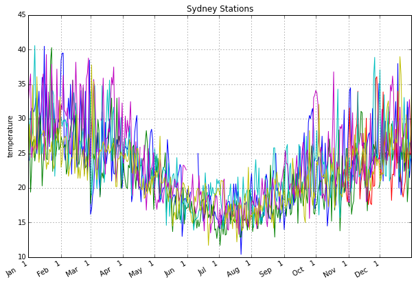

```python
YearlyPlots(tmp.ix[3:368,:],ttl='Sydney Stations')
```

### Computing mean and std for each station/year

```python
# a simple scale function to normalize the data-frame row-by-row
from numpy import mean, std
def scale_temps(Din):
    matrix=Din.iloc[:,3:]
    Dout=Din.loc[:,['station','year']+range(1,366)]
    Mean=mean(matrix, axis=1).values
    Dout['Mean']=Mean
    Std= std(matrix, axis=1).values
    Dout['Std']=Std
    Dout.loc[:,3:368]=matrix.values
    return Dout

#Call function, it adds 2 more columns; Mean and Std
Dout=scale_temps(Data)
#reorder the columns
Dout=Dout[['station','year','Mean','Std']+range(1,366)]
print Dout.info()
Dout.head()
```

```
<class 'pandas.core.frame.DataFrame'>
Int64Index: 20000 entries, 0 to 19999
Columns: 369 entries, station to 365
dtypes: float64(367), int64(1), object(1)
memory usage: 56.5+ MB
None
```

|  | station | year | Mean | Std | 1 | 2 | 3 | 4 | 5 | 6 | ... | 356 | 357 | 358 | 359 | 360 | 361 | 362 | 363 | 364 | 365 |
| --- | --- | --- | --- | --- | --- | --- | --- | --- | --- | --- | --- | --- | --- | --- | --- | --- | --- | --- | --- | --- | --- |
| 0 | USC00507570 | 2005 | 6.1 | 10.439819 | 6.7 | 6.7 | 4.4 | 6.1 | 1.7 | -1.7 | ... | -2.8 | -3.9 | -3.3 | -1.7 | 3.9 | 6.1 | 5.0 | 6.1 | 6.1 | 4.4 |
| 1 | NOE00135018 | 1959 | 6.1 | 7.974400 | NaN | NaN | NaN | NaN | NaN | NaN | ... | 8.0 | 5.8 | 3.1 | 4.5 | 4.2 | 3.2 | 1.6 | 2.0 | 2.2 | 3.9 |
| 2 | KZ000036546 | 1982 | -9.9 | 14.897310 | NaN | NaN | NaN | -13.9 | NaN | NaN | ... | NaN | NaN | -7.3 | NaN | NaN | NaN | -17.0 | -16.6 | -16.0 | -13.5 |
| 3 | USC00054664 | 1964 | -15.0 | 10.790115 | NaN | NaN | NaN | NaN | NaN | NaN | ... | 6.7 | 9.4 | 7.8 | 3.3 | NaN | NaN | 3.9 | 5.6 | -3.9 | -15.0 |
| 4 | CUW00011706 | 1981 | 31.1 | 1.588618 | 30.0 | 30.0 | 28.3 | 30.0 | 30.0 | 28.3 | ... | 28.9 | 30.0 | 31.1 | 32.2 | 31.1 | 31.1 | 32.2 | 32.2 | 31.1 | 31.1 |

5 rows × 369 columns

### Compute average temperature for each day of the year.

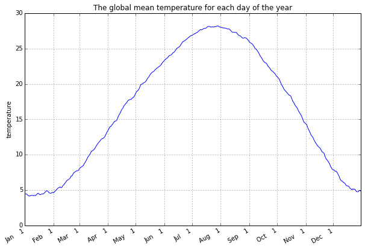

```python
Mean=mean(Dout.ix[:,4:369], axis=0)
YearlyPlots(Mean,ttl='The global mean temperature for each day of the year')
```

## Principle Component Analysis

An explanation of the principle component analysis (PCA) can be found in [Wikipedia](https://en.wikipedia.org/wiki/Principal_component_analysis). The site [setosa.io](http://setosa.io/ev/principal-component-analysis/) contains a nice interactive visualization of PCA.

In this section we use PCA to model the main ways in which temperarature along the year varies between stations. We start by cleaning the data.

### Missing Values

We find the distribution of missing values and decide how to deal with them. From the analysis below we see that most rows have some missing values. We therefor choose to perform the average more carefully, rather than discard rows with many missing values

```
3783
```

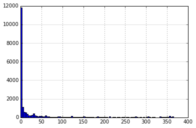

```python
nan_per_row=sum(isnan(Dout.ix[:,4:369]),axis=1)
nan_per_row.hist(bins=100)
sum(nan_per_row>50)
```

### NaN-tolerant averaging

In the code below I remove all rows that have a nan in them. If you remve the command **M.dropna(...** then all rows are used. Can you get better results without removing the rows?

```python
Dout.info()
Dout.head()
```

```
<class 'pandas.core.frame.DataFrame'>
Int64Index: 20000 entries, 0 to 19999
Columns: 369 entries, station to 365
dtypes: float64(367), int64(1), object(1)
memory usage: 56.5+ MB
```

|  | station | year | Mean | Std | 1 | 2 | 3 | 4 | 5 | 6 | ... | 356 | 357 | 358 | 359 | 360 | 361 | 362 | 363 | 364 | 365 |
| --- | --- | --- | --- | --- | --- | --- | --- | --- | --- | --- | --- | --- | --- | --- | --- | --- | --- | --- | --- | --- | --- |
| 0 | USC00507570 | 2005 | 6.1 | 10.439819 | 6.7 | 6.7 | 4.4 | 6.1 | 1.7 | -1.7 | ... | -2.8 | -3.9 | -3.3 | -1.7 | 3.9 | 6.1 | 5.0 | 6.1 | 6.1 | 4.4 |
| 1 | NOE00135018 | 1959 | 6.1 | 7.974400 | NaN | NaN | NaN | NaN | NaN | NaN | ... | 8.0 | 5.8 | 3.1 | 4.5 | 4.2 | 3.2 | 1.6 | 2.0 | 2.2 | 3.9 |
| 2 | KZ000036546 | 1982 | -9.9 | 14.897310 | NaN | NaN | NaN | -13.9 | NaN | NaN | ... | NaN | NaN | -7.3 | NaN | NaN | NaN | -17.0 | -16.6 | -16.0 | -13.5 |
| 3 | USC00054664 | 1964 | -15.0 | 10.790115 | NaN | NaN | NaN | NaN | NaN | NaN | ... | 6.7 | 9.4 | 7.8 | 3.3 | NaN | NaN | 3.9 | 5.6 | -3.9 | -15.0 |
| 4 | CUW00011706 | 1981 | 31.1 | 1.588618 | 30.0 | 30.0 | 28.3 | 30.0 | 30.0 | 28.3 | ... | 28.9 | 30.0 | 31.1 | 32.2 | 31.1 | 31.1 | 32.2 | 32.2 | 31.1 | 31.1 |

5 rows × 369 columns

```python
#Get the columns
M=Dout.ix[:,4:369]
print M.info()
M.head()
```

```
<class 'pandas.core.frame.DataFrame'>
Int64Index: 20000 entries, 0 to 19999
Columns: 365 entries, 1 to 365
dtypes: float64(365)
memory usage: 55.8 MB
None
```

|  | 1 | 2 | 3 | 4 | 5 | 6 | 7 | 8 | 9 | 10 | ... | 356 | 357 | 358 | 359 | 360 | 361 | 362 | 363 | 364 | 365 |
| --- | --- | --- | --- | --- | --- | --- | --- | --- | --- | --- | --- | --- | --- | --- | --- | --- | --- | --- | --- | --- | --- |
| 0 | 6.7 | 6.7 | 4.4 | 6.1 | 1.7 | -1.7 | -2.2 | -3.9 | -4.4 | -4.4 | ... | -2.8 | -3.9 | -3.3 | -1.7 | 3.9 | 6.1 | 5.0 | 6.1 | 6.1 | 4.4 |
| 1 | NaN | NaN | NaN | NaN | NaN | NaN | NaN | NaN | NaN | NaN | ... | 8.0 | 5.8 | 3.1 | 4.5 | 4.2 | 3.2 | 1.6 | 2.0 | 2.2 | 3.9 |
| 2 | NaN | NaN | NaN | -13.9 | NaN | NaN | -4.5 | NaN | NaN | -2.8 | ... | NaN | NaN | -7.3 | NaN | NaN | NaN | -17.0 | -16.6 | -16.0 | -13.5 |
| 3 | NaN | NaN | NaN | NaN | NaN | NaN | NaN | NaN | NaN | NaN | ... | 6.7 | 9.4 | 7.8 | 3.3 | NaN | NaN | 3.9 | 5.6 | -3.9 | -15.0 |
| 4 | 30.0 | 30.0 | 28.3 | 30.0 | 30.0 | 28.3 | 28.9 | 28.9 | 31.1 | 30.0 | ... | 28.9 | 30.0 | 31.1 | 32.2 | 31.1 | 31.1 | 32.2 | 32.2 | 31.1 | 31.1 |

5 rows × 365 columns

```python
M=M.dropna(axis=0)
M.info()
```

```
<class 'pandas.core.frame.DataFrame'>
Int64Index: 8906 entries, 0 to 19999
Columns: 365 entries, 1 to 365
dtypes: float64(365)
memory usage: 24.9 MB
```

```python
(columns,rows)=shape(M)
Mean=mean(M, axis=0).values
print columns, rows
```

```
8906 365
```

```python
print (columns,rows), shape(Mean)
C=np.zeros([columns,columns])   # Sum
N=np.zeros([columns,columns])   # Counter of non-nan entries
print shape(M)
print C, N
```

```
(8906, 365) (365,)
(8906, 365)
[[ 0.  0.  0. ...,  0.  0.  0.]
 [ 0.  0.  0. ...,  0.  0.  0.]
 [ 0.  0.  0. ...,  0.  0.  0.]
 ...,
 [ 0.  0.  0. ...,  0.  0.  0.]
 [ 0.  0.  0. ...,  0.  0.  0.]
 [ 0.  0.  0. ...,  0.  0.  0.]] [[ 0.  0.  0. ...,  0.  0.  0.]
 [ 0.  0.  0. ...,  0.  0.  0.]
 [ 0.  0.  0. ...,  0.  0.  0.]
 ...,
 [ 0.  0.  0. ...,  0.  0.  0.]
 [ 0.  0.  0. ...,  0.  0.  0.]
 [ 0.  0.  0. ...,  0.  0.  0.]]
```

```python
from sklearn.decomposition import PCA

K=5
pca = PCA(n_components=K)
#M is data which as 9K rows and 365 columns
pca.fit(M)

#Transfrom the data (M): 9K rows and 365 columns
T=pca.transform(M)
```

```python
#         shape: gives the axis dimensions of the object, consistent with ndarray
#         Axis labels
#             Series: index (only axis)
#             DataFrame: index (rows) and columns
#             Panel: items, major_axis, and minor_axis
T.shape
```

```
(8906, 5)
```

```python
shape(pca.components_)
```

```
(5, 365)
```

### Percentage of variance Explained

```
<type 'numpy.ndarray'>
[ 0.61475401  0.72380931  0.73570249  0.7451763   0.75208831]
5
[ 0.61475401  0.1090553   0.01189319  0.00947381  0.00691201]
```

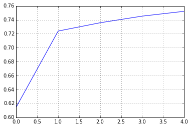

```python
cumulative_explained = cumsum(pca.explained_variance_ratio_)
print type(cumulative_explained), '\n', cumulative_explained, '\n', len(cumulative_explained)
plot(cumulative_explained);
#xlim([0,365])
grid()

print pca.explained_variance_ratio_[:10]
```

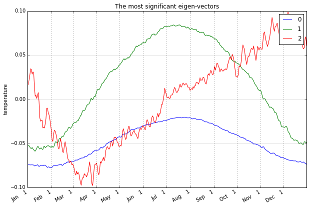

```python
k=3 # number of components to show.
Tcomp=np.transpose(pca.components_)
YearlyPlots(Tcomp[:,:k],ttl='The most significant eigen-vectors')
legend(range(0,k));
```

```python
k=5
Eig=np.matrix(Tcomp[:,:k])
#print [np.linalg.norm(U[:,i]) for i in range(k)]
matrix=np.matrix(Dout.ix[:,4:369])-Mean
matrix[isnan(matrix)]=0
print shape(Eig),shape(matrix)
Prod=matrix*Eig;
print shape(Prod)
```

```
(365, 5) (20000, 365)
(20000, 5)
```

Insert coefficients for k top eigenvectors into the dataframe **Dout**

```python
for i in range(k-1,-1,-1):
    Ser=pd.Series(np.array(Prod)[:,i],index=Dout.index)
    Dout.insert(4,'V'+str(i),Ser)
Dout.head()
```

|  | station | year | Mean | Std | V0 | V1 | V2 | V3 | V4 | 1 | ... | 356 | 357 | 358 | 359 | 360 | 361 | 362 | 363 | 364 | 365 |
| --- | --- | --- | --- | --- | --- | --- | --- | --- | --- | --- | --- | --- | --- | --- | --- | --- | --- | --- | --- | --- | --- |
| 0 | USC00507570 | 2005 | 6.1 | 10.439819 | 142.542335 | -53.142058 | -34.698023 | 0.024229 | -24.861489 | 6.7 | ... | -2.8 | -3.9 | -3.3 | -1.7 | 3.9 | 6.1 | 5.0 | 6.1 | 6.1 | 4.4 |
| 1 | NOE00135018 | 1959 | 6.1 | 7.974400 | 57.748468 | -51.203735 | -21.655675 | -19.200017 | 1.373847 | NaN | ... | 8.0 | 5.8 | 3.1 | 4.5 | 4.2 | 3.2 | 1.6 | 2.0 | 2.2 | 3.9 |
| 2 | KZ000036546 | 1982 | -9.9 | 14.897310 | 55.448199 | 26.623664 | -6.348335 | 4.354367 | 1.750808 | NaN | ... | NaN | NaN | -7.3 | NaN | NaN | NaN | -17.0 | -16.6 | -16.0 | -13.5 |
| 3 | USC00054664 | 1964 | -15.0 | 10.790115 | 22.136002 | 10.280194 | -22.612768 | -20.692641 | 6.074010 | NaN | ... | 6.7 | 9.4 | 7.8 | 3.3 | NaN | NaN | 3.9 | 5.6 | -3.9 | -15.0 |
| 4 | CUW00011706 | 1981 | 31.1 | 1.588618 | -314.497357 | -24.905930 | 9.185746 | 5.780095 | -4.897360 | 30.0 | ... | 28.9 | 30.0 | 31.1 | 32.2 | 31.1 | 31.1 | 32.2 | 32.2 | 31.1 | 31.1 |

5 rows × 374 columns

### Longitude,Latitude information

Loading the station longitude/latitude and merging it into the Table

```python
!ls
```

```
ALL.corrupted.csv           ghcnd-readme.txt
ALL.head.csv                ghcnd-stations.txt
SAMPLE_TMAX.csv             ghcnd-stations_buffered.txt
TMAX.10.csv                 ghcnd-version.txt
TMAX.head.csv               make_covar.raw_256
data-source.txt
```

```python
!cat ghcnd-readme.txt   # uncomment to read the readme file.
```

```python
# Make all lines be of length 90 to solve problem wilth read_fwf
out=open('ghcnd-stations_buffered.txt','w')
for line in open('ghcnd-stations.txt','r').readlines():
    line=line.rstrip()
    string=line+' '*(90-len(line))+'\n'
    out.write(string)
out.close()
print string
```

```
ZI000067991 -22.2170   30.0000  457.0    BEITBRIDGE                             67991
```

```python
colspecs = [(0, 11), (11, 21), (21, 31), (31, 38),(39,41),(41,72),(72,76),(76,80),(80,86)]

#pandas.read_fwf(filepath_or_buffer, colspecs='infer', widths=None, **kwds)
#Read a table of fixed-width formatted lines into DataFrame
stations = pd.read_fwf('ghcnd-stations_buffered.txt', colspecs=colspecs, header=None, index_col=0,
                       names=['latitude','longitude','elevation','state','name','GSNFLAG','HCNFLAG','WMOID'])
```

```python
#stations['elevation'][stations['elevation']==-999.9]=0  # decided not to remove -999.9 because this confuses hist
```

```python
lama = stations[['latitude', 'longitude', 'elevation']]
#df.dropna(subset = ['column1_name', 'column2_name', 'column3_name'])
lama = lama.dropna(subset = ['latitude', 'longitude', 'elevation'])
"""
#lama = lama.values.tolist()
lon = lama[['longitude']]
lon = lon.values.tolist()

lat = lama[['latitude']]
lat = lat.values.tolist()

ele = lama[['elevation']]
ele = ele.values.tolist()
"""
```

```
"\n#lama = lama.values.tolist()\nlon = lama[['longitude']]\nlon = lon.values.tolist()\n\nlat = lama[['latitude']]\nlat = lat.values.tolist()\n\nele = lama[['elevation']]\nele = ele.values.tolist()\n"
```

### perform a **JOIN**

Join the geographical information into **Dout**, creating a new dataframe called **Djoined**

```python
print Dout.info()
print stations.shape
```

```
<class 'pandas.core.frame.DataFrame'>
Int64Index: 20000 entries, 0 to 19999
Columns: 374 entries, station to 365
dtypes: float64(372), int64(1), object(1)
memory usage: 57.2+ MB
None
(85284, 8)
```

```python
Djoined=Dout.join(stations,on='station')
Djoined.info()
Djoined.head()
```

```
<class 'pandas.core.frame.DataFrame'>
Int64Index: 20000 entries, 0 to 19999
Columns: 382 entries, station to WMOID
dtypes: float64(376), int64(1), object(5)
memory usage: 58.4+ MB
```

|  | station | year | Mean | Std | V0 | V1 | V2 | V3 | V4 | 1 | ... | 364 | 365 | latitude | longitude | elevation | state | name | GSNFLAG | HCNFLAG | WMOID |
| --- | --- | --- | --- | --- | --- | --- | --- | --- | --- | --- | --- | --- | --- | --- | --- | --- | --- | --- | --- | --- | --- |
| 0 | USC00507570 | 2005 | 6.1 | 10.439819 | 142.542335 | -53.142058 | -34.698023 | 0.024229 | -24.861489 | 6.7 | ... | 6.1 | 4.4 | 60.2036 | -154.3164 | 79.2 | K | PORT ALSWORTH | NaN | NaN | NaN |
| 1 | NOE00135018 | 1959 | 6.1 | 7.974400 | 57.748468 | -51.203735 | -21.655675 | -19.200017 | 1.373847 | NaN | ... | 2.2 | 3.9 | 59.2300 | 10.3481 | 26.0 | NaN | MELSOM | NaN | NaN | NaN |
| 2 | KZ000036546 | 1982 | -9.9 | 14.897310 | 55.448199 | 26.623664 | -6.348335 | 4.354367 | 1.750808 | NaN | ... | -16.0 | -13.5 | 48.5500 | 83.6830 | 427.0 | NaN | KURCUM | NaN | NaN | 36546 |
| 3 | USC00054664 | 1964 | -15.0 | 10.790115 | 22.136002 | 10.280194 | -22.612768 | -20.692641 | 6.074010 | NaN | ... | -3.9 | -15.0 | 40.0575 | -106.3681 | 2273.8 | O | KREMMLING | NaN | NaN | NaN |
| 4 | CUW00011706 | 1981 | 31.1 | 1.588618 | -314.497357 | -24.905930 | 9.185746 | 5.780095 | -4.897360 | 30.0 | ... | 31.1 | 31.1 | 19.9000 | -75.1500 | 16.2 | NaN | GUANTANAMO BAY NAS | GSN | NaN | 78367 |

5 rows × 382 columns

```python
Djoined.columns[-10:]
```

```
Index([         364,          365,  u'latitude', u'longitude', u'elevation',
           u'state',      u'name',   u'GSNFLAG',   u'HCNFLAG',     u'WMOID'],
      dtype='object')
```

```python
Djoined['AbsLatitude']=abs(Djoined['latitude'].values)
```

```python
Djoined.ix[:5,['station',u'longitude','latitude',u'AbsLatitude','Mean','Std','V0','V1','V2']]
```

|  | station | longitude | latitude | AbsLatitude | Mean | Std | V0 | V1 | V2 |
| --- | --- | --- | --- | --- | --- | --- | --- | --- | --- |
| 0 | USC00507570 | -154.3164 | 60.2036 | 60.2036 | 6.1 | 10.439819 | 142.542335 | -53.142058 | -34.698023 |
| 1 | NOE00135018 | 10.3481 | 59.2300 | 59.2300 | 6.1 | 7.974400 | 57.748468 | -51.203735 | -21.655675 |
| 2 | KZ000036546 | 83.6830 | 48.5500 | 48.5500 | -9.9 | 14.897310 | 55.448199 | 26.623664 | -6.348335 |
| 3 | USC00054664 | -106.3681 | 40.0575 | 40.0575 | -15.0 | 10.790115 | 22.136002 | 10.280194 | -22.612768 |
| 4 | CUW00011706 | -75.1500 | 19.9000 | 19.9000 | 31.1 | 1.588618 | -314.497357 | -24.905930 | 9.185746 |
| 5 | KG000036982 | 78.2330 | 41.8830 | 41.8830 | -15.0 | 2.500000 | 1.128783 | 0.711891 | -1.415106 |

### Looking for significant correlations and dependencies

```python
#  DataFrame.cov(min_periods=None)
#     Compute pairwise covariance of columns, excluding NA/null values
#Compare the colums to themselves: rows and colums are tracing to each others
Djoined[['latitude','elevation','Mean','Std','V0','V1','V2','V3','V4']].cov()
```

|  | latitude | elevation | Mean | Std | V0 | V1 | V2 | V3 | V4 |
| --- | --- | --- | --- | --- | --- | --- | --- | --- | --- |
| latitude | 357.338215 | 610.684430 | -163.997185 | 32.995352 | 1677.543112 | 489.335460 | 3.921011 | -48.111049 | -15.072878 |
| elevation | 610.684430 | 402304.438251 | -1049.397827 | 147.390961 | 10074.281065 | 287.160177 | -847.465198 | -2575.110178 | 933.566189 |
| Mean | -163.997185 | -1049.397827 | 163.872457 | -28.754266 | -1490.197012 | -175.515449 | 45.411416 | 32.948075 | -5.461178 |
| Std | 32.995352 | 147.390961 | -28.754266 | 10.885685 | 294.176303 | 85.734401 | -4.033802 | -0.668544 | -2.367896 |
| V0 | 1677.543112 | 10074.281065 | -1490.197012 | 294.176303 | 18132.598680 | 110.784416 | -4.739785 | -117.142857 | -102.171351 |
| V1 | 489.335460 | 287.160177 | -175.515449 | 85.734401 | 110.784416 | 3194.812901 | 15.151201 | 20.132160 | -12.633344 |
| V2 | 3.921011 | -847.465198 | 45.411416 | -4.033802 | -4.739785 | 15.151201 | 548.360463 | 80.001461 | 3.676441 |
| V3 | -48.111049 | -2575.110178 | 32.948075 | -0.668544 | -117.142857 | 20.132160 | 80.001461 | 369.975263 | 6.073503 |
| V4 | -15.072878 | 933.566189 | -5.461178 | -2.367896 | -102.171351 | -12.633344 | 3.676441 | 6.073503 | 240.124732 |

The correlations between different $V_i$ components should be zero, which it isn't. Is this due to numerical roundoff errors? Are the correlations statistically significant for this sample size?

```python
#  DataFrame.corr(method='pearson', min_periods=1)
#     Compute pairwise correlation of columns, excluding NA/null values
Djoined[['latitude','elevation','Mean','Std','V0','V1','V2','V3','V4']].corr()
#
# https://en.wikipedia.org/wiki/Pearson_product-moment_correlation_coefficient
```

|  | latitude | elevation | Mean | Std | V0 | V1 | V2 | V3 | V4 |
| --- | --- | --- | --- | --- | --- | --- | --- | --- | --- |
| latitude | 1.000000 | 0.050933 | -0.692939 | 0.529138 | 0.659028 | 0.457978 | 0.008858 | -0.132318 | -0.051456 |
| elevation | 0.050933 | 1.000000 | -0.129984 | 0.070434 | 0.117952 | 0.008010 | -0.057057 | -0.211073 | 0.094984 |
| Mean | -0.692939 | -0.129984 | 1.000000 | -0.726310 | -0.838980 | -0.236631 | 0.159373 | 0.136793 | -0.027806 |
| Std | 0.529138 | 0.070434 | -0.726310 | 1.000000 | 0.662090 | 0.459697 | -0.052206 | -0.010534 | -0.046311 |
| V0 | 0.659028 | 0.117952 | -0.838980 | 0.662090 | 1.000000 | 0.014555 | -0.001503 | -0.045227 | -0.048964 |
| V1 | 0.457978 | 0.008010 | -0.236631 | 0.459697 | 0.014555 | 1.000000 | 0.011447 | 0.018517 | -0.014424 |
| V2 | 0.008858 | -0.057057 | 0.159373 | -0.052206 | -0.001503 | 0.011447 | 1.000000 | 0.177615 | 0.010132 |
| V3 | -0.132318 | -0.211073 | 0.136793 | -0.010534 | -0.045227 | 0.018517 | 0.177615 | 1.000000 | 0.020377 |
| V4 | -0.051456 | 0.094984 | -0.027806 | -0.046311 | -0.048964 | -0.014424 | 0.010132 | 0.020377 | 1.000000 |

```python
# Choosing significance threshold so that none of the correlations between the Vi-s are significant.
abs(Djoined[['latitude','elevation','Mean','Std','V0','V1','V2','V3','V4']].corr())>0.2
```

|  | latitude | elevation | Mean | Std | V0 | V1 | V2 | V3 | V4 |
| --- | --- | --- | --- | --- | --- | --- | --- | --- | --- |
| latitude | True | False | True | True | True | True | False | False | False |
| elevation | False | True | False | False | False | False | False | True | False |
| Mean | True | False | True | True | True | True | False | False | False |
| Std | True | False | True | True | True | True | False | False | False |
| V0 | True | False | True | True | True | False | False | False | False |
| V1 | True | False | True | True | False | True | False | False | False |
| V2 | False | False | False | False | False | False | True | False | False |
| V3 | False | True | False | False | False | False | False | True | False |
| V4 | False | False | False | False | False | False | False | False | True |

```python
# Seems to take enormous amount of time
from pandas.tools.plotting import scatter_matrix
```

```python
df = Djoined.ix[:,['latitude','elevation','Mean','Std','V0','V1','V2','V3','V4']]
```

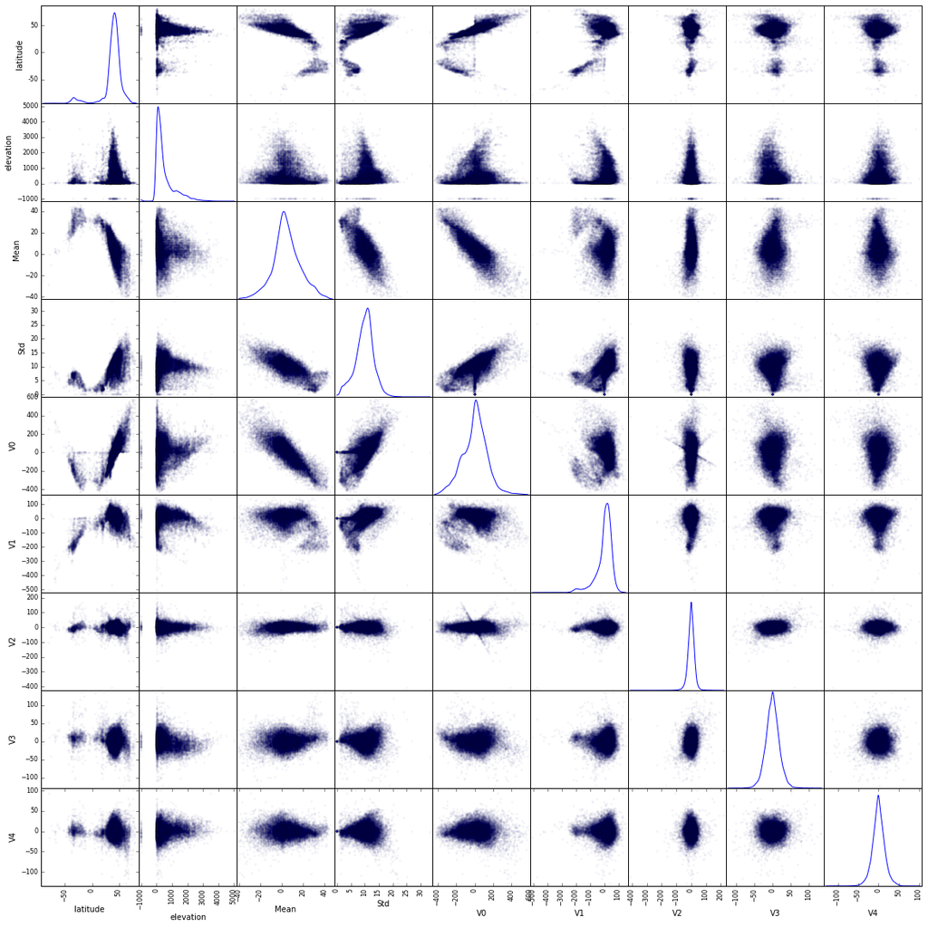

```python
scatter_matrix(df,alpha=0.03, figsize=(20, 20), diagonal='kde');
```

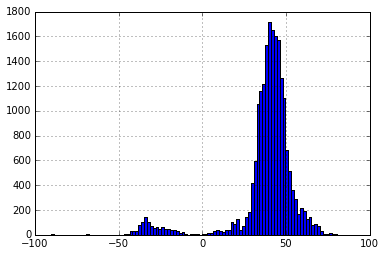

```python
X='latitude'
Djoined.ix[:,X].hist(bins=100);
```

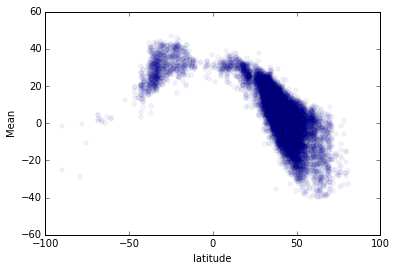

```python
X='latitude';Y='Mean'
scatter(Djoined.loc[:,X],Djoined.loc[:,Y],alpha=0.05)
xlabel(X)
ylabel(Y)
```

```python
#checking for an anomaly in the elevations of stations
Djoined[['station','elevation']][Djoined['elevation']<-500].head()
```

|  | station | elevation |
| --- | --- | --- |
| 1244 | USC00301010 | -999.9 |
| 1312 | USC00095231 | -999.9 |
| 1747 | RSM00023707 | -999.9 |
| 1821 | BL000085041 | -999.9 |
| 2192 | USC00107878 | -999.9 |

```python
!grep ASN00010865 ghcnd-stations.txt
```

```
ASN00010865 -34.0333  117.2667 -999.9    LUMEAH
```

### Plotting maps

Working through http://matplotlib.org/basemap/

- http://en.wikipedia.org/wiki/Map_projection
- http://matplotlib.org/basemap/users/mapsetup.html

```python
lons=Djoined.ix[:,'longitude'].values
lats=Djoined.ix[:,'latitude'].values
Djoined=Djoined.dropna(subset = ['state'])
#ele=Djoined.ix[:,'elevation'].values
station_names=Djoined.index.values
ll=len(lons)
lonmin=-135;lonmax=-54;latsmin=22;latsmax=49;
#llcrnrlat=22,urcrnrlon=-64,urcrnrlat=49
select=(lons>lonmin) * (lons<lonmax)*(lats>latsmin)*(lats<latsmax)
print sum(select)
station_names=station_names[select]
lons=lons[select]
lats=lats[select]
#ele =ele[select]
print len(lons),len(lats),len(station_names)
```

```
12396
12396 12396 12396
```

To get to these coordinate on Google Maps, type the latitude and longitude in decimal in the search box or use: https://www.google.com/maps/place/72%C2%B018'00.0%22S+170%C2%B013'00.1%22E/@-72.3,170.216694,17z/data=!3m1!4b1!4m2!3m1!1s0x0:0x0

Questions

1. Write a script that will do that automatically from python i.e write a script in python return the google maps url when passed with the latitude and longitudinal values of the place
2. Can you create a map where the denity of points is represented as a density map (topographical map)?
3. Can you create a map that would represent, using color, the values of a chosen column (Mean, Std, V0,V1 etc.)? What conclusions can you draw from this map?

```python
# 1.
def Q1GoogleMapsUrl(lon, lat):
    maps='https://www.google.com/maps/@'
    url = maps + lat + ',' + lon + ',17z'
    return url

# lat -2.163106 Somewhere in the amazon (Brazil)
# lon -55.126648
lat='-2.163106'
lon='-55.126648'
Q1GoogleMapsUrl(lon,lat)
```

```
'https://www.google.com/maps/@-2.163106,-55.126648,17z'
```

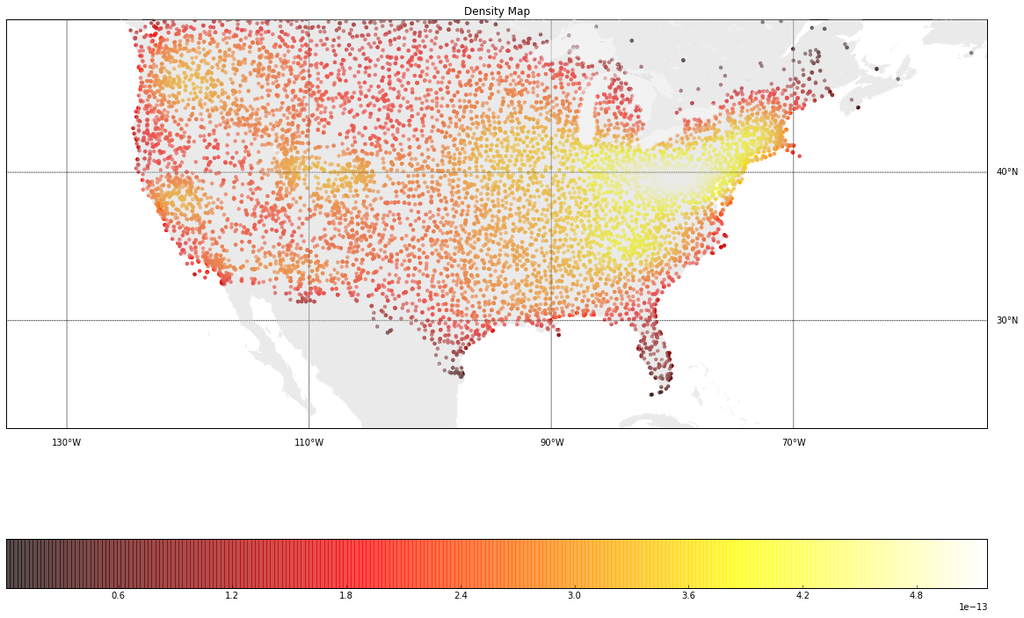

```python
#2
# http://matplotlib.org/basemap/users/merc.html
from mpl_toolkits.basemap import Basemap
import matplotlib.cm as cm
import numpy as np
import matplotlib.pyplot as plt
from scipy.stats import gaussian_kde

fig = plt.figure(figsize=(20,15),dpi=900)


#llcrnrlon=-119,llcrnrlat=22,urcrnrlon=-64,urcrnrlat=49
m = Basemap(projection='merc',llcrnrlat=latsmin,urcrnrlat=latsmax,\
            llcrnrlon=lonmin,urcrnrlon=lonmax,lat_ts=60,lat_1=33,lat_2=45,lon_0=-95, resolution='h')
#m.drawcoastlines()
m.fillcontinents(color='0.8', lake_color=None, ax=None, zorder='0', alpha=.4)


# draw parallels and meridians.
parallels = np.arange(-80,81,10.)
# labels = [left,right,top,bottom]
m.drawparallels(parallels,labels=[False,True,True,False])
meridians = np.arange(10.,351.,20.)
m.drawmeridians(meridians,labels=[True,False,False,True])

#m.drawparallels(np.arange(-90.,91.,30.))
#m.drawmeridians(np.arange(-180.,181.,60.))
m.drawmapboundary(fill_color=None)
#http://stackoverflow.com/questions/15854878/correlation-between-columns-in-dataframe

# draw map with markers for locations
x, y = m(lons,lats)
xy = np.vstack([x,y])
z = gaussian_kde(xy)(xy)
#m.plot(lons,y,'g.')
#m.contourf(lon,lat,ele,cmap=cm.s3pcpn)

#m.scatter(lons, lats, c=ele,s = 200, cmap='afmhot')
#plt.colorbar()
sc = m.scatter(x,y,s=20,c=z,marker="o",edgecolor='',alpha = .7, cmap=cm.hot)

plt.colorbar(sc, orientation='horizontal')
plt.title('Density Map')
plt.show()
```

```python
# 3

from scipy.stats import gaussian_kde
import matplotlib.cm as cm


def chosenColumn(parameter):

    #lonmin=-180;lonmax=-30;latsmin=0;latsmax=80;
    lonmin=-135;lonmax=-54;latsmin=22;latsmax=49;
    plt.figure(figsize=(15,10),dpi=300)
    m = Basemap(projection='merc',llcrnrlat=latsmin,urcrnrlat=latsmax,\
            llcrnrlon=lonmin,urcrnrlon=lonmax,lat_ts=60,lat_1=33,lat_2=45,lon_0=-95, resolution='h')
    m.drawcoastlines()
    m.fillcontinents(color='0.8',lake_color=None, ax=None, zorder='0', alpha=0.4)

    # draw parallels and meridians.
    parallels = np.arange(-80,81,10.)
    # labels = [left,right,top,bottom]
    m.drawparallels(parallels,labels=[False,True,True,False])
    meridians = np.arange(10.,351.,20.)
    m.drawmeridians(meridians,labels=[True,False,False,True])

    #m.drawparallels(np.arange(-90.,91.,30.))
    #m.drawmeridians(np.arange(-180.,181.,60.))
    m.drawmapboundary(fill_color=None)

    # Using USA coordinates only
    lons=Djoined.ix[:,'longitude'].values
    lats=Djoined.ix[:,'latitude'].values
    vals=Djoined.ix[:,parameter].values
    select=(lons>lonmin)*(lons<lonmax)*(lats>latsmin)*(lats<latsmax)*(~isnan(lats))*(~isnan(lons))
    lons=lons[select]
    lats=lats[select]
    vals=vals[select]

    # draw map with markers for locations
    x, y = m(lons,lats)
    sc=m.scatter(x, y, c=vals, s=20, edgecolor='', marker='o',cmap=cm.winter, zorder='1')
    plt.colorbar(sc)
    plt.title(parameter, fontsize=16)
    plt.show()
```

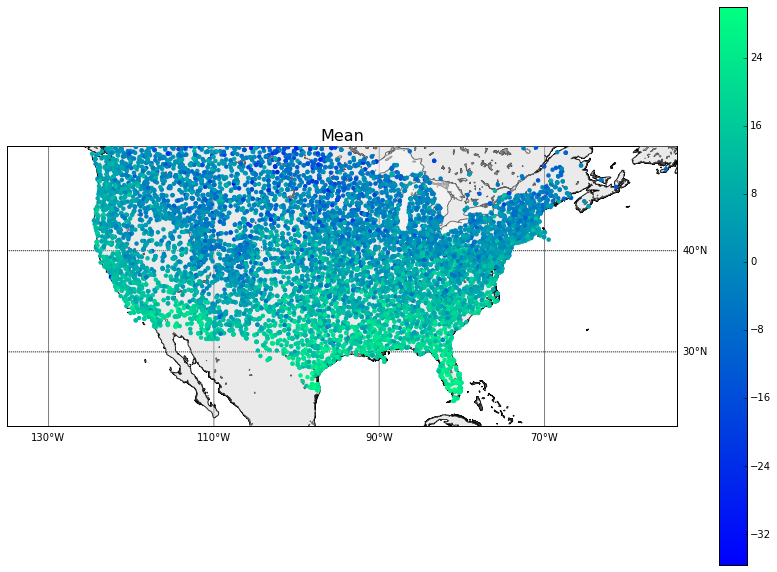

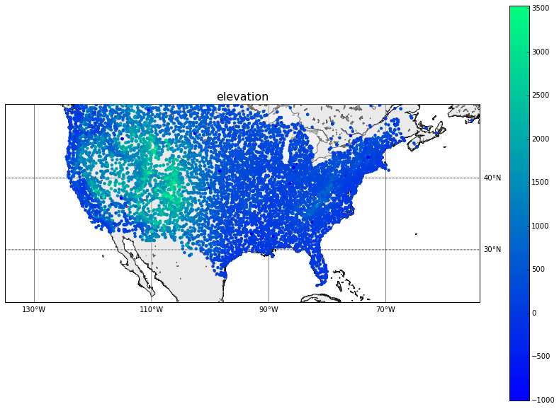

```python
chosenColumn('Mean')
chosenColumn('elevation')
#From this chart, it is clear that it is colder up north and in
#Colorado. The elevation chart is interesting in that it shows a correlation
# between elevation and colder temperature.
```

### Reconstruction

```python
print Eig.shape, T.transpose().shape
Eig=np.array(Eig)
print type(Eig),type(T)
plot(Eig[:,0:3]);
```

[output not shown]

```python
print T.shape[0]
```

[output not shown]

```python
np.prod?
```

```python
%matplotlib inline
def plot_reconstructions(T,K=40,rows=2,columns=7):
    Recon=np.mat(Eig[:,:K])*np.mat(T[:K,:])+Mean[:,np.newaxis]
    Recon=np.array(Recon)
    #return Recon
    plt.figure(figsize=(columns*3,rows*3),dpi=300)
    j=0;
    for i in range(T.shape[1]):
        subplot(rows,columns,j);
        j += 1;
        if j>=rows*columns: break
        plot(Recon[1:,i])
        plot(Djoined.ix[i,1:365]);
        title(Djoined.ix[i,'station']+' / '+str(Djoined.ix[i,'year']))
        xlim([0,365])
```

```python
plot(Djoined.ix[20,1:365])
```

[output not shown]

```python
plot_reconstructions(T[:10,:].transpose(),rows=7,columns=3)
```

[output not shown]

Check how the approximations change/improve as you increase the number of coefficients

```python
hist(Djoined.ix[:,'V0'],bins=100);
print Djoined['State']
```

[output not shown]

Can you reduce the reconstruction error (using a fixed number of eigenvectors) by splitting the stations according to region (for example country, state, latitudal range). Note that having a regions with very few readings defeats the purpose.